# Car Selling Price

**Comments to Critiquers:**

1. When do you look at and find meaning in the $p$-value of the Y-intercept? It seems like I am usually looking at the slope’s and/or other variables’ $p$-values.
2. Have we discussed how do we use the values of $\sqrt{MSE}$ and $R^2$ like we do with the $p$-value?
3. If you take a look at my assumption plots, I would like to manually name the Residuals vs Fitted and QQ Plot. How do I do this? Currently, Normal Q-Q is showing up underneath my Residuals vs. Fitted title.
4. How do I order my dataset to descend by `Year`? So I would like the dataset to start with 2019 and go down to 19–.
5. I cannot determine why my stat() functions are not working. The linearity and variance appear to be off when running my diagnostics and so I ran a BoxCox plot for a Y-transformation to correct the regression line. I show I need to run a log on y. But, I am getting a warning message of “Computation failed in `stat_function()`: non-numeric argument to binary operator”. Am I running the correct transformation?
6. How do I change the x axis to show correct numbers?
7. How do I center my graph?

**Corrections**

1. I added values 85ish to 112 to provide more information on trucks above 200,000 miles and information between trucks costing `$12,000` and `$25,000`.
2. I corrected my Background statement to reflect that I own a XLT Ford Ranger and not a XL. The data has a cross of XL and xLT.
3. Under the `Information from Model` section, I added an explanation of what $R^2$ is telling me.
4. In the `Checking Assumption`, I added an explanation of $\sqrt{MSE}$ and italicized straight and both in the paragraph to add emphasis to what I am doing with a transformation.
5. I added a section called `Transformed Assumptions`.
6. Why is the simple regression line going into `$-10,000`? I mean that’s what’s predicted, but is this correct or do I need to make changes to reflect the car’s value can’t go below `$0.00$`?
7. Did I label the devaluation per mile correctly?

## Background

I own a 1997 Ford Ranger XLT with 256,000 miles. It was actually provided to me by my cousin and so I do not know the exact value/purchasing price of my truck. I would like to determine at what point/mileage do I need to sell this car or if it is *way* too late to sell it.

## Summary

### Findings

```r
mylm <- lm(Pricing ~ Mileage, data = SellPrice)
mylm.co <- mylm$coefficients
mylm.t <- lm(log(Pricing) ~ Mileage, data = SellPrice)
mylm.log <- mylm.t$coefficients
mylines.t <- exp(predict(mylm.t, data.frame(Mileage=100000), interval="prediction"))
#mylines <- predict(mylm, data.frame(Mileage=100000), interval="prediction")
```

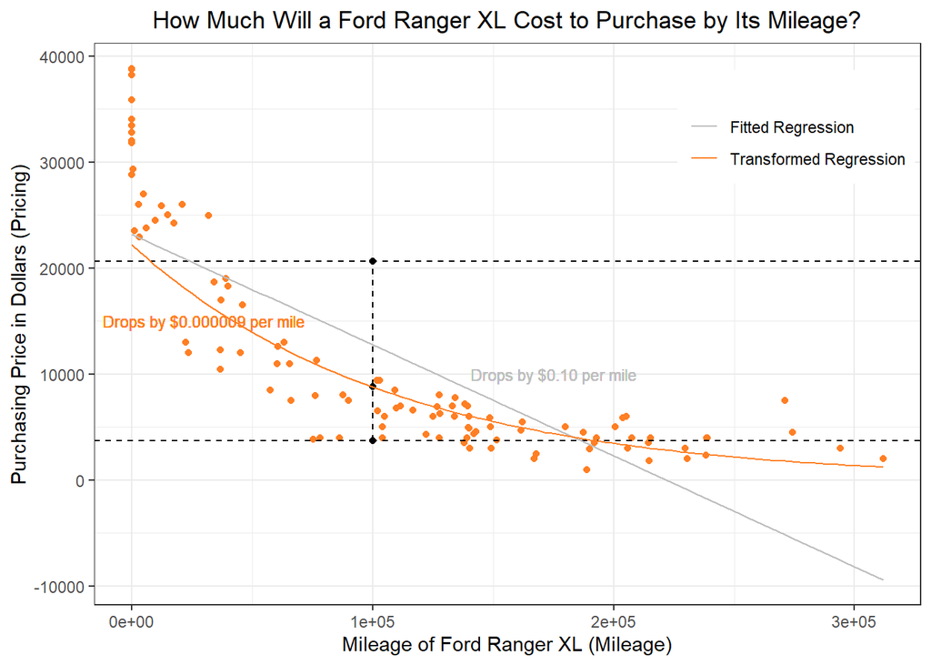

```r
SellPrice %>%
  ggplot() +
  aes(y = Pricing, x = as.numeric(Mileage)) +
  geom_point(color = "chocolate1") +
  geom_point(aes(x = 100000, y = mylines.t[1]), color = "black") +
  geom_point(aes(x = 100000, y = mylines.t[2]), color = "black") +
  geom_point(aes(x = 100000, y = mylines.t[3]), color = "black") +
  geom_hline(aes(yintercept = mylines.t[2]), color = "black", linetype = 2) +
  geom_hline(aes(yintercept = mylines.t[3]), color = "black", linetype = 2) +
  geom_segment(aes(x=100000, xend=100000, y=mylines.t[2], yend=mylines.t[3]), color="black", linetype = 2) + # mylines[2] lowend mylines[3] highend
  stat_function(fun = function(x)(mylm.co[1] + mylm.co[2]*x),
                aes(color = "a")) +
  stat_function(fun = function(x)exp(mylm.log[1] + mylm.log[2]*x),
                aes(color = "b")) +
  labs(x = "Mileage of Ford Ranger XL (Mileage)",
       y = "Purchasing Price in Dollars (Pricing)",
       title = "How Much Will a Ford Ranger XL Cost to Purchase by Its Mileage?") +
  theme_bw() +
  theme(plot.title = element_text(hjust = 0.5),
        legend.position = c(0.85, .85)) +
  scale_color_manual("",
                     values = c("gray", "chocolate1"),
                     labels = c("Fitted Regression", "Transformed Regression")) +
  geom_text(x = 175000,
            y = 10000,
            label = "Drops by $0.10 per mile",
            color = "gray",
            size = 3) +
  geom_text(x = 30000,
            y = 15000,
            label = "Drops by $0.000009 per mile",
            color = "chocolate1",
            size = 3)
```

Selling a Ford Ranger XL or XLT around the $\le 100,000$ mileage mark seems to be the best option after running this regression. The linearity of the corrected regression line still shows some abnormality, but I don’t believe it’s enough to forgo my findings. According to my prediction, I will be able to sell a Ford Ranger with 100,000 miles anywhere from `$3,737.12` to `$20,648.95`.

### Analysis

In order to perform this regression, I will use a simple regression mathmatical formula. But for the linear model to provide any meaning, $\beta_1$ cannot equal 0. If it does, than our null hypothesis is correct, $\beta_1$ = 0. This will then render the simple linear analysis useless to determine the purchasing price of a Ford Ranger XL or XLT by the mileage. A significant result will fare from $\alpha \le 0.05$. Here is the mathematical formula:

$$\underbrace{Y_i}_\text{Purchase Price} = \overbrace{
\underbrace{\beta_0}_\text{Y-int} \ +
\ \underbrace{\beta_1}_\text{Slope} \ \ \underbrace{X_i}_\text{Mileage}}^\text{Regression Line} +
\epsilon_i \quad \text{where} \ \epsilon_i \sim N(0, \sigma^2)$$

Since we do not have information for all Ford Ranger XL’s or XLT’s mileage and purchasing price, I will be using this estimation of the regression model:

$$\underbrace{\hat{Y_i}}_\text{Purchase Price} = b_0 + b_1 \underbrace{X_i}_\text{Mileage}$$

#### Information from Model

```r
mylm <- lm(Pricing ~ Mileage, data = SellPrice)
mylm.co <- mylm$coefficients
#summary(mylm)

pander(summary(mylm))
```

|  | Estimate | Std. Error | t value | Pr(>\|t\|) |
| --- | --- | --- | --- | --- |
| **(Intercept)** | 23204 | 1004 | 23.11 | 8.255e-44 |
| **Mileage** | -0.1045 | 0.007453 | -14.02 | 3.747e-26 |

Fitting linear model: Pricing ~ Mileage

| Observations | Residual Std. Error | $R^2$ | Adjusted $R^2$ |
| --- | --- | --- | --- |
| 111 | 6469 | 0.6433 | 0.6401 |

This linear regression model is actually a great fit because both of our $p$-values for the Intercept and Milege are $<2e-16$. And in this linear model, we are taking into consideration the Intercept’s $p$-value because if $\beta_1$, or the x variable, were to equal zero we would want to still know the value of $y$, or the purchasing price. However, it seems that our current linear model explains 64% of the data points’ variability. We will look at the assumptions plots to verify if all assumptions are met for this linear model to fully work.

#### Checking Assumptions

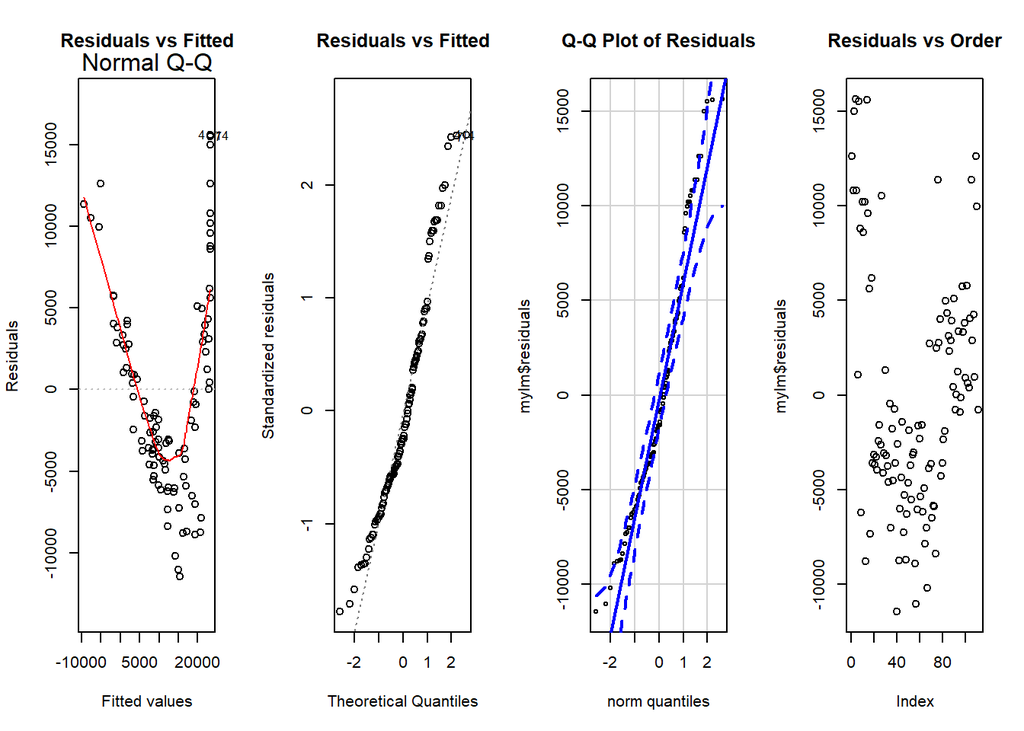

```r
# Check Assumptions

par(mfrow=c(1,4))
plot(mylm, which=1:2, main = "Residuals vs Fitted", "Normal Q-Q")
qqPlot(mylm$residuals, main = "Q-Q Plot of Residuals", id = FALSE)
plot(mylm$residuals, main = "Residuals vs Order")
```

```r
#plot(mylm, which = 1)
# qqPlot(mylm$residuals, main = "Q-Q Plot of Residuals", id = FALSE)
```

The variance and linearity of this dataset is terrible. The variance in our data is going to then mess with our $\sqrt{MSE}$ (the average amount a data point deviates from the regression line) and our ability to plot a *straight* regression line due to the linearity issue. In order to fix *both* the variance and linearity, I have ran a BoxCox plot to diagnose what Y-transformated regression line needs to be created.

#### Transformation

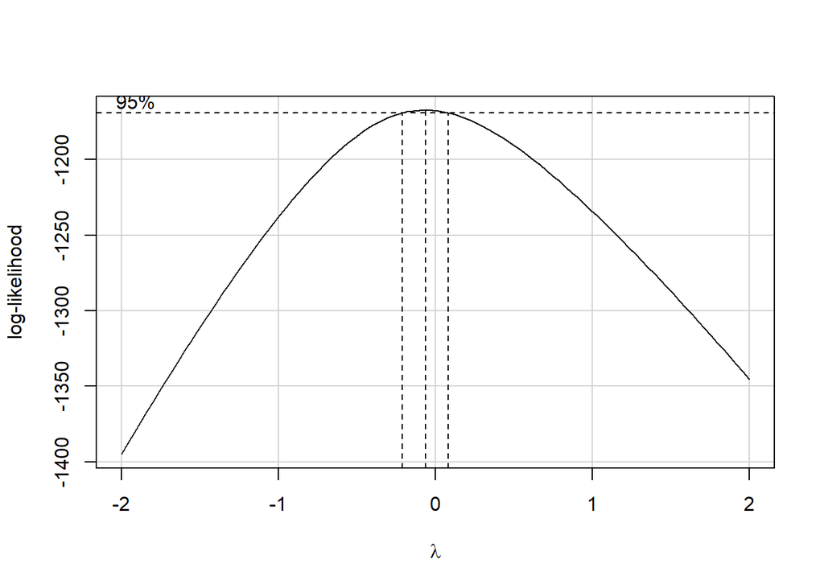

```r
boxCox(mylm)
```

It appears that I will need to take the log() of `Pricing` in order to transform the regression line.

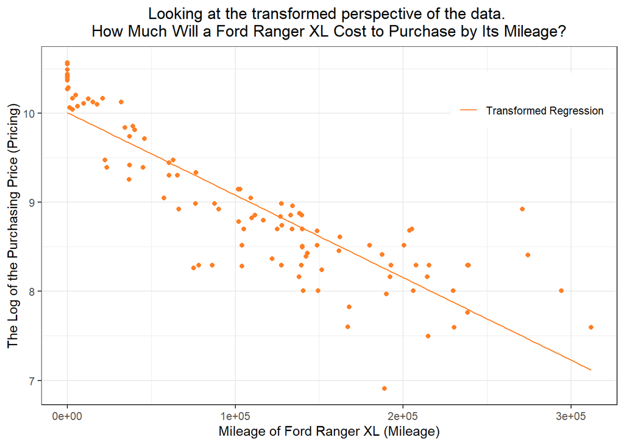

```r
mylm.t <- lm(log(Pricing) ~ Mileage, data = SellPrice)
mylm.log <- mylm.t$coefficients

SellPrice %>%
  ggplot() +
  aes(y = log(Pricing), x = Mileage) +
  geom_point(color = "chocolate1") +
  stat_function(fun = function(x)(mylm.log[1] + mylm.log[2]*x),
                aes(color = "b")) +
  labs(x = "Mileage of Ford Ranger XL (Mileage)",
       y = "The Log of the Purchasing Price (Pricing)",
       title = "Looking at the transformed perspective of the data. \nHow Much Will a Ford Ranger XL Cost to Purchase by Its Mileage?") +
  theme_bw() +
  theme(plot.title = element_text(hjust = 0.5),
        legend.position = c(0.85, .85)) +
  scale_color_manual("",
                     values = c("chocolate1"),
                     labels = c("Transformed Regression"))
```

#### Transformed Assumptions

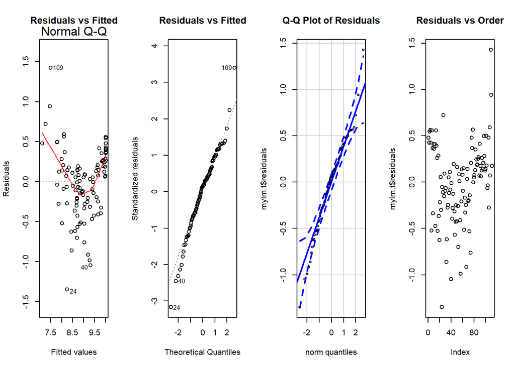

```r
par(mfrow=c(1,4))
plot(mylm.t, which=1:2, main = "Residuals vs Fitted", "Normal Q-Q")
qqPlot(mylm.t$residuals, main = "Q-Q Plot of Residuals", id = FALSE)
plot(mylm.t$residuals, main = "Residuals vs Order")
```

It looks like I may not be able to accurately determine what the regression line is because the linearity of the data is still abnormal when I run the diagnostic plots, but I think this model is much better. Let’s see what the summary of the linear model for the transformation states to determine if this a better fit.

```r
pander(summary(mylm.t))
```

|  | Estimate | Std. Error | t value | Pr(>\|t\|) |
| --- | --- | --- | --- | --- |
| **(Intercept)** | 10.01 | 0.06663 | 150.2 | 3.627e-128 |
| **Mileage** | -9.26e-06 | 4.946e-07 | -18.72 | 7.612e-36 |

Fitting linear model: log(Pricing) ~ Mileage

| Observations | Residual Std. Error | $R^2$ | Adjusted $R^2$ |
| --- | --- | --- | --- |
| 111 | 0.4293 | 0.7628 | 0.7606 |

```r
pander(exp(predict(mylm.t, data.frame(Mileage=100000), interval="prediction")))
```

| fit | lwr | upr |
| --- | --- | --- |
| 8785 | 3737 | 20649 |

```r
pander(predict(mylm, data.frame(Mileage=100000), interval="prediction"))
```

| fit | lwr | upr |
| --- | --- | --- |
| 12753 | -127.6 | 25633 |

### Show Data

I retrieved this data from [KSL Auto](https://cars.ksl.com/search?p=&make%5B%5D=Ford&model%5B%5D=Ranger&trim%5B%5D=XL&page=0), [CarMax](https://www.carmax.com/cars/ford/ranger), and [True Car](https://www.truecar.com/used-cars-for-sale/listings/ford/ranger/?trimSlug%5B%5D=xl).

```r
datatable(SellPrice)
```

|  | Year | Make | Model | Mileage | Pricing | City | State |
| --- | --- | --- | --- | --- | --- | --- | --- |
| 1 | 2019 | Ford | Ranger XL | 1 | 35837 | Layton | UT |
| 2 | 2019 | Ford | Ranger XL | 7 | 34002 | Spanish Fork | UT |
| 3 | 2019 | Ford | Ranger XL | 26 | 38182 | Layton | UT |
| 4 | 2019 | Ford | Ranger XL | 1 | 38824 | Layton | UT |
| 5 | 2019 | Ford | Ranger XL | 8 | 34002 | Spanish Fork | UT |
| 6 | 1995 | Ford | Ranger XL | 214853 | 1800 | North Salt Lake | UT |
| 7 | 2019 | Ford | Ranger XL | 29 | 38703 | Layton | UT |
| 8 | 2019 | Ford | Ranger XL | 20 | 31989 | Morgan | UT |
| 9 | 2000 | Ford | Ranger XL | 105017 | 5995 | Sandy | UT |
| 10 | 2019 | Ford | Ranger XL | 7 | 33414 | Draper | UT |

[output cut: 101 more lines]